# Exploratory Data Analysis of automobile data set

by [Bienvenu CHOUPO](https://www.linkedin.com/in/bienvenu-choupo)  
10 September 2019

Hi everyone! We have a set of automobile data available online. You can donwload it [HERE](https://s3-api.us-geo.objectstorage.softlayer.net/cf-courses-data/CognitiveClass/DA0101EN/automobileEDA.csv)

### In this document, we will explore several methods to see if certain characteristics or features can be used to predict car price.

## Table of content

1. Import Data
2. Analyzing Individual Feature Patterns using Visualization
3. Descriptive Statistical Analysis
4. Grouping
5. Correlation and Causation
6. ANOVA

### What are the main characteristics which have the most impact on the car price?

## 1. Import Data

Let's first import libraries

```
Libraries imported
```

We load data and store in dataframe df:

|  | symboling | normalized-losses | make | aspiration | num-of-doors | body-style | drive-wheels | engine-location | wheel-base | length | ... | compression-ratio | horsepower | peak-rpm | city-mpg | highway-mpg | price | city-L/100km | horsepower-binned | diesel | gas |
| --- | --- | --- | --- | --- | --- | --- | --- | --- | --- | --- | --- | --- | --- | --- | --- | --- | --- | --- | --- | --- | --- |
| 0 | 3 | 122 | alfa-romero | std | two | convertible | rwd | front | 88.6 | 0.811148 | ... | 9.0 | 111.0 | 5000.0 | 21 | 27 | 13495.0 | 11.190476 | Medium | 0 | 1 |
| 1 | 3 | 122 | alfa-romero | std | two | convertible | rwd | front | 88.6 | 0.811148 | ... | 9.0 | 111.0 | 5000.0 | 21 | 27 | 16500.0 | 11.190476 | Medium | 0 | 1 |
| 2 | 1 | 122 | alfa-romero | std | two | hatchback | rwd | front | 94.5 | 0.822681 | ... | 9.0 | 154.0 | 5000.0 | 19 | 26 | 16500.0 | 12.368421 | Medium | 0 | 1 |
| 3 | 2 | 164 | audi | std | four | sedan | fwd | front | 99.8 | 0.848630 | ... | 10.0 | 102.0 | 5500.0 | 24 | 30 | 13950.0 | 9.791667 | Medium | 0 | 1 |
| 4 | 2 | 164 | audi | std | four | sedan | 4wd | front | 99.4 | 0.848630 | ... | 8.0 | 115.0 | 5500.0 | 18 | 22 | 17450.0 | 13.055556 | Medium | 0 | 1 |

5 rows × 29 columns

```
Our Dataframe has  201  rows and  29  columns
```

## 2. Analyzing Individual Feature Patterns using Visualization

#### How to choose the right visualization method?

When visualizing individual variables, it is important to first understand what type of variable you are dealing with. This will help us find the right visualization method for that variable.

Let's se the data types of different columns

```
symboling              int64
normalized-losses      int64
make                  object
aspiration            object
num-of-doors          object
body-style            object
drive-wheels          object
engine-location       object
wheel-base           float64
length               float64
width                float64
height               float64
curb-weight            int64
engine-type           object
num-of-cylinders      object
engine-size            int64
fuel-system           object
bore                 float64
stroke               float64
compression-ratio    float64
horsepower           float64
peak-rpm             float64
city-mpg               int64
highway-mpg            int64
price                float64
city-L/100km         float64
horsepower-binned     object
diesel                 int64
gas                    int64
dtype: object
```

let's calculate the correlation between variables of type "int64" or "float64" :

|  | symboling | normalized-losses | wheel-base | length | width | height | curb-weight | engine-size | bore | stroke | compression-ratio | horsepower | peak-rpm | city-mpg | highway-mpg | price | city-L/100km | diesel | gas |
| --- | --- | --- | --- | --- | --- | --- | --- | --- | --- | --- | --- | --- | --- | --- | --- | --- | --- | --- | --- |
| symboling | 1.000000 | 0.466264 | -0.535987 | -0.365404 | -0.242423 | -0.550160 | -0.233118 | -0.110581 | -0.140019 | -0.008245 | -0.182196 | 0.075819 | 0.279740 | -0.035527 | 0.036233 | -0.082391 | 0.066171 | -0.196735 | 0.196735 |
| normalized-losses | 0.466264 | 1.000000 | -0.056661 | 0.019424 | 0.086802 | -0.373737 | 0.099404 | 0.112360 | -0.029862 | 0.055563 | -0.114713 | 0.217299 | 0.239543 | -0.225016 | -0.181877 | 0.133999 | 0.238567 | -0.101546 | 0.101546 |
| wheel-base | -0.535987 | -0.056661 | 1.000000 | 0.876024 | 0.814507 | 0.590742 | 0.782097 | 0.572027 | 0.493244 | 0.158502 | 0.250313 | 0.371147 | -0.360305 | -0.470606 | -0.543304 | 0.584642 | 0.476153 | 0.307237 | -0.307237 |
| length | -0.365404 | 0.019424 | 0.876024 | 1.000000 | 0.857170 | 0.492063 | 0.880665 | 0.685025 | 0.608971 | 0.124139 | 0.159733 | 0.579821 | -0.285970 | -0.665192 | -0.698142 | 0.690628 | 0.657373 | 0.211187 | -0.211187 |
| width | -0.242423 | 0.086802 | 0.814507 | 0.857170 | 1.000000 | 0.306002 | 0.866201 | 0.729436 | 0.544885 | 0.188829 | 0.189867 | 0.615077 | -0.245800 | -0.633531 | -0.680635 | 0.751265 | 0.673363 | 0.244356 | -0.244356 |
| height | -0.550160 | -0.373737 | 0.590742 | 0.492063 | 0.306002 | 1.000000 | 0.307581 | 0.074694 | 0.180449 | -0.062704 | 0.259737 | -0.087027 | -0.309974 | -0.049800 | -0.104812 | 0.135486 | 0.003811 | 0.281578 | -0.281578 |
| curb-weight | -0.233118 | 0.099404 | 0.782097 | 0.880665 | 0.866201 | 0.307581 | 1.000000 | 0.849072 | 0.644060 | 0.167562 | 0.156433 | 0.757976 | -0.279361 | -0.749543 | -0.794889 | 0.834415 | 0.785353 | 0.221046 | -0.221046 |
| engine-size | -0.110581 | 0.112360 | 0.572027 | 0.685025 | 0.729436 | 0.074694 | 0.849072 | 1.000000 | 0.572609 | 0.209523 | 0.028889 | 0.822676 | -0.256733 | -0.650546 | -0.679571 | 0.872335 | 0.745059 | 0.070779 | -0.070779 |
| bore | -0.140019 | -0.029862 | 0.493244 | 0.608971 | 0.544885 | 0.180449 | 0.644060 | 0.572609 | 1.000000 | -0.055390 | 0.001263 | 0.566936 | -0.267392 | -0.582027 | -0.591309 | 0.543155 | 0.554610 | 0.054458 | -0.054458 |
| stroke | -0.008245 | 0.055563 | 0.158502 | 0.124139 | 0.188829 | -0.062704 | 0.167562 | 0.209523 | -0.055390 | 1.000000 | 0.187923 | 0.098462 | -0.065713 | -0.034696 | -0.035201 | 0.082310 | 0.037300 | 0.241303 | -0.241303 |
| compression-ratio | -0.182196 | -0.114713 | 0.250313 | 0.159733 | 0.189867 | 0.259737 | 0.156433 | 0.028889 | 0.001263 | 0.187923 | 1.000000 | -0.214514 | -0.435780 | 0.331425 | 0.268465 | 0.071107 | -0.299372 | 0.985231 | -0.985231 |
| horsepower | 0.075819 | 0.217299 | 0.371147 | 0.579821 | 0.615077 | -0.087027 | 0.757976 | 0.822676 | 0.566936 | 0.098462 | -0.214514 | 1.000000 | 0.107885 | -0.822214 | -0.804575 | 0.809575 | 0.889488 | -0.169053 | 0.169053 |
| peak-rpm | 0.279740 | 0.239543 | -0.360305 | -0.285970 | -0.245800 | -0.309974 | -0.279361 | -0.256733 | -0.267392 | -0.065713 | -0.435780 | 0.107885 | 1.000000 | -0.115413 | -0.058598 | -0.101616 | 0.115830 | -0.475812 | 0.475812 |
| city-mpg | -0.035527 | -0.225016 | -0.470606 | -0.665192 | -0.633531 | -0.049800 | -0.749543 | -0.650546 | -0.582027 | -0.034696 | 0.331425 | -0.822214 | -0.115413 | 1.000000 | 0.972044 | -0.686571 | -0.949713 | 0.265676 | -0.265676 |
| highway-mpg | 0.036233 | -0.181877 | -0.543304 | -0.698142 | -0.680635 | -0.104812 | -0.794889 | -0.679571 | -0.591309 | -0.035201 | 0.268465 | -0.804575 | -0.058598 | 0.972044 | 1.000000 | -0.704692 | -0.930028 | 0.198690 | -0.198690 |
| price | -0.082391 | 0.133999 | 0.584642 | 0.690628 | 0.751265 | 0.135486 | 0.834415 | 0.872335 | 0.543155 | 0.082310 | 0.071107 | 0.809575 | -0.101616 | -0.686571 | -0.704692 | 1.000000 | 0.789898 | 0.110326 | -0.110326 |
| city-L/100km | 0.066171 | 0.238567 | 0.476153 | 0.657373 | 0.673363 | 0.003811 | 0.785353 | 0.745059 | 0.554610 | 0.037300 | -0.299372 | 0.889488 | 0.115830 | -0.949713 | -0.930028 | 0.789898 | 1.000000 | -0.241282 | 0.241282 |
| diesel | -0.196735 | -0.101546 | 0.307237 | 0.211187 | 0.244356 | 0.281578 | 0.221046 | 0.070779 | 0.054458 | 0.241303 | 0.985231 | -0.169053 | -0.475812 | 0.265676 | 0.198690 | 0.110326 | -0.241282 | 1.000000 | -1.000000 |
| gas | 0.196735 | 0.101546 | -0.307237 | -0.211187 | -0.244356 | -0.281578 | -0.221046 | -0.070779 | -0.054458 | -0.241303 | -0.985231 | 0.169053 | 0.475812 | -0.265676 | -0.198690 | -0.110326 | 0.241282 | -1.000000 | 1.000000 |

The diagonal elements are always one; we will study correlation more precisely Pearson correlation in-depth at the end of the notebook.

## Continuous numerical variables:

In order to start understanding the (linear) relationship between an individual variable and the price. We can do this by using "regplot", which plots the scatterplot plus the fitted regression line for the data.

Let's see several examples of different linear relationships:

### Linear relationship

Let's find the scatterplot of "engine-size" and "price"

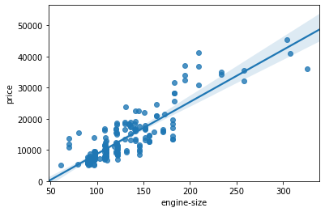

As the engine-size goes up, the price goes up: this indicates a positive direct correlation between these two variables. Engine size seems like a pretty good predictor of price since the regression line is almost a perfect diagonal line.

We can examine the correlation between 'engine-size' and 'price' and see it's approximately 0.87

|  | engine-size | price |
| --- | --- | --- |
| engine-size | 1.000000 | 0.872335 |
| price | 0.872335 | 1.000000 |

Highway mpg is a potential predictor variable of price

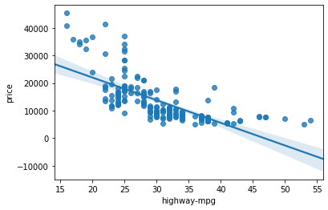

As the highway-mpg goes up, the price goes down: this indicates an inverse/negative relationship between these two variables. Highway mpg could potentially be a predictor of price.

We can examine the correlation between 'highway-mpg' and 'price' and see it's approximately -0.704

|  | highway-mpg | price |
| --- | --- | --- |
| highway-mpg | 1.000000 | -0.704692 |
| price | -0.704692 | 1.000000 |

##### Weak Linear Relationship

Let's see if "Peak-rpm" as a predictor variable of "price".

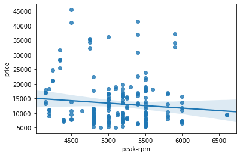

Peak rpm does not seem like a good predictor of the price at all since the regression line is close to horizontal. Also, the data points are very scattered and far from the fitted line, showing lots of variability. Therefore it's it is not a reliable variable.

We can examine the correlation between 'peak-rpm' and 'price' and see it's approximately -0.101616

|  | peak-rpm | price |
| --- | --- | --- |
| peak-rpm | 1.000000 | -0.101616 |
| price | -0.101616 | 1.000000 |

### Categorical variables

A good way to visualize categorical variables is by using boxplots.

Let's look at the relationship between "body-style" and "price".

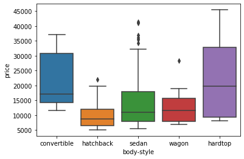

We see that the distributions of price between the different body-style categories have a significant overlap, and so body-style would not be a good predictor of price. Let's examine engine "engine-location" and "price":

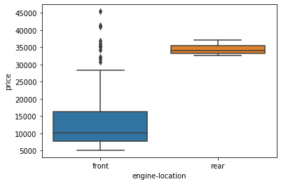

Here we see that the distribution of price between these two engine-location categories, front and rear, are distinct enough to take engine-location as a potential good predictor of price.

Let's examine "drive-wheels" and "price".

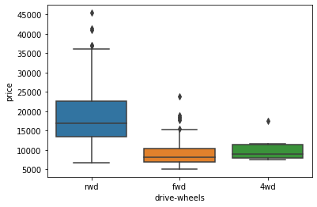

Here we see that the distribution of price between the different drive-wheels categories differs; as such drive-wheels could potentially be a predictor of price.

## 3. Descriptive Statistical Analysis

Let's first take a look at the variables by utilizing a description method.

|  | symboling | normalized-losses | wheel-base | length | width | height | curb-weight | engine-size | bore | stroke | compression-ratio | horsepower | peak-rpm | city-mpg | highway-mpg | price | city-L/100km | diesel | gas |
| --- | --- | --- | --- | --- | --- | --- | --- | --- | --- | --- | --- | --- | --- | --- | --- | --- | --- | --- | --- |
| count | 201.000000 | 201.00000 | 201.000000 | 201.000000 | 201.000000 | 201.000000 | 201.000000 | 201.000000 | 201.000000 | 197.000000 | 201.000000 | 201.000000 | 201.000000 | 201.000000 | 201.000000 | 201.000000 | 201.000000 | 201.000000 | 201.000000 |
| mean | 0.840796 | 122.00000 | 98.797015 | 0.837102 | 0.915126 | 53.766667 | 2555.666667 | 126.875622 | 3.330692 | 3.256904 | 10.164279 | 103.405534 | 5117.665368 | 25.179104 | 30.686567 | 13207.129353 | 9.944145 | 0.099502 | 0.900498 |
| std | 1.254802 | 31.99625 | 6.066366 | 0.059213 | 0.029187 | 2.447822 | 517.296727 | 41.546834 | 0.268072 | 0.319256 | 4.004965 | 37.365700 | 478.113805 | 6.423220 | 6.815150 | 7947.066342 | 2.534599 | 0.300083 | 0.300083 |
| min | -2.000000 | 65.00000 | 86.600000 | 0.678039 | 0.837500 | 47.800000 | 1488.000000 | 61.000000 | 2.540000 | 2.070000 | 7.000000 | 48.000000 | 4150.000000 | 13.000000 | 16.000000 | 5118.000000 | 4.795918 | 0.000000 | 0.000000 |
| 25% | 0.000000 | 101.00000 | 94.500000 | 0.801538 | 0.890278 | 52.000000 | 2169.000000 | 98.000000 | 3.150000 | 3.110000 | 8.600000 | 70.000000 | 4800.000000 | 19.000000 | 25.000000 | 7775.000000 | 7.833333 | 0.000000 | 1.000000 |
| 50% | 1.000000 | 122.00000 | 97.000000 | 0.832292 | 0.909722 | 54.100000 | 2414.000000 | 120.000000 | 3.310000 | 3.290000 | 9.000000 | 95.000000 | 5125.369458 | 24.000000 | 30.000000 | 10295.000000 | 9.791667 | 0.000000 | 1.000000 |
| 75% | 2.000000 | 137.00000 | 102.400000 | 0.881788 | 0.925000 | 55.500000 | 2926.000000 | 141.000000 | 3.580000 | 3.410000 | 9.400000 | 116.000000 | 5500.000000 | 30.000000 | 34.000000 | 16500.000000 | 12.368421 | 0.000000 | 1.000000 |
| max | 3.000000 | 256.00000 | 120.900000 | 1.000000 | 1.000000 | 59.800000 | 4066.000000 | 326.000000 | 3.940000 | 4.170000 | 23.000000 | 262.000000 | 6600.000000 | 49.000000 | 54.000000 | 45400.000000 | 18.076923 | 1.000000 | 1.000000 |

The default setting of "describe" skips variables of type object. We can apply the method "describe" on the variables of type 'object':

|  | make | aspiration | num-of-doors | body-style | drive-wheels | engine-location | engine-type | num-of-cylinders | fuel-system | horsepower-binned |
| --- | --- | --- | --- | --- | --- | --- | --- | --- | --- | --- |
| count | 201 | 201 | 201 | 201 | 201 | 201 | 201 | 201 | 201 | 200 |
| unique | 22 | 2 | 2 | 5 | 3 | 2 | 6 | 7 | 8 | 3 |
| top | toyota | std | four | sedan | fwd | front | ohc | four | mpfi | Low |
| freq | 32 | 165 | 115 | 94 | 118 | 198 | 145 | 157 | 92 | 115 |

### Value Counts

Let's see how many units of each characteristic/variable we have.  
With the variable 'drive-wheels':

| drive-wheels | value_counts |
| --- | --- |
| fwd | 118 |
| rwd | 75 |
| 4wd | 8 |

With the variable 'engine-location':

| engine-location | value_counts |
| --- | --- |
| front | 198 |
| rear | 3 |

Examining the value counts of the engine location would not be a good predictor variable for the price. This is because we only have three cars with a rear engine and 198 with an engine in the front, this result is skewed. Thus, we are not able to draw any conclusions about the engine location.

## 4. Grouping

Let's group by the variable "drive-wheels". We see that there are 3 different categories of drive wheels.

```
array(['rwd', 'fwd', '4wd'], dtype=object)
```

On average, which type of drive wheel is most valuable?

|  | drive-wheels | body-style | price |
| --- | --- | --- | --- |
| 0 | rwd | convertible | 13495.0 |
| 1 | rwd | convertible | 16500.0 |
| 2 | rwd | hatchback | 16500.0 |
| 3 | fwd | sedan | 13950.0 |
| 4 | 4wd | sedan | 17450.0 |

Let's calculate the average price for each of the different categories of data.

|  | drive-wheels | price |
| --- | --- | --- |
| 0 | 4wd | 10241.000000 |
| 1 | fwd | 9244.779661 |
| 2 | rwd | 19757.613333 |

From our data, it seems rear-wheel drive vehicles are, on average, the most expensive, while 4-wheel and front-wheel are approximately the same in price.

Let's group by both 'drive-wheels' and 'body-style'.</p>

|  | drive-wheels | body-style | price |
| --- | --- | --- | --- |
| 0 | 4wd | hatchback | 7603.000000 |
| 1 | 4wd | sedan | 12647.333333 |
| 2 | 4wd | wagon | 9095.750000 |
| 3 | fwd | convertible | 11595.000000 |
| 4 | fwd | hardtop | 8249.000000 |
| 5 | fwd | hatchback | 8396.387755 |
| 6 | fwd | sedan | 9811.800000 |
| 7 | fwd | wagon | 9997.333333 |
| 8 | rwd | convertible | 23949.600000 |
| 9 | rwd | hardtop | 24202.714286 |
| 10 | rwd | hatchback | 14337.777778 |
| 11 | rwd | sedan | 21711.833333 |
| 12 | rwd | wagon | 16994.222222 |

This grouped data is much easier to visualize when it is made into a pivot table.

We fill the missing values with 0

| body-style drive-wheels | price convertible | price hardtop | price hatchback | price sedan | price wagon |
| --- | --- | --- | --- | --- | --- |
| 4wd | 0.0 | 0.000000 | 7603.000000 | 12647.333333 | 9095.750000 |
| fwd | 11595.0 | 8249.000000 | 8396.387755 | 9811.800000 | 9997.333333 |
| rwd | 23949.6 | 24202.714286 | 14337.777778 | 21711.833333 | 16994.222222 |

#### Variables: Drive Wheels and Body Style vs Price

Let's use a heat map to visualize the relationship between Body Style vs Price.

The heatmap plots the target variable (price) proportional to colour with respect to the variables 'drive-wheel' and 'body-style' in the vertical and horizontal axis respectively. This allows us to visualize how the price is related to 'drive-wheel' and 'body-style'.

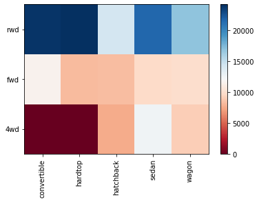

The main question we want to answer in this document is "What are the main characteristics which have the most impact on the car price?".

To get a better measure of the important characteristics, we look at the correlation of these variables with the car price, in other words: how is the car price dependent on this variable?

## 5. Correlation and Causation

Pearson Correlation</p>

The Pearson Correlation measures the linear dependence between two variables X and Y.

The resulting coefficient is a value between -1 and 1 inclusive, where:

- **1**: Total positive linear correlation.
- **0**: No linear correlation, the two variables most likely do not affect each other.
- **-1**: Total negative linear correlation.

As we stated before we can calculate the Pearson Correlation of the of the 'int64' or 'float64' variables.

|  | symboling | normalized-losses | wheel-base | length | width | height | curb-weight | engine-size | bore | stroke | compression-ratio | horsepower | peak-rpm | city-mpg | highway-mpg | price | city-L/100km | diesel | gas |
| --- | --- | --- | --- | --- | --- | --- | --- | --- | --- | --- | --- | --- | --- | --- | --- | --- | --- | --- | --- |
| symboling | 1.000000 | 0.466264 | -0.535987 | -0.365404 | -0.242423 | -0.550160 | -0.233118 | -0.110581 | -0.140019 | -0.008245 | -0.182196 | 0.075819 | 0.279740 | -0.035527 | 0.036233 | -0.082391 | 0.066171 | -0.196735 | 0.196735 |
| normalized-losses | 0.466264 | 1.000000 | -0.056661 | 0.019424 | 0.086802 | -0.373737 | 0.099404 | 0.112360 | -0.029862 | 0.055563 | -0.114713 | 0.217299 | 0.239543 | -0.225016 | -0.181877 | 0.133999 | 0.238567 | -0.101546 | 0.101546 |
| wheel-base | -0.535987 | -0.056661 | 1.000000 | 0.876024 | 0.814507 | 0.590742 | 0.782097 | 0.572027 | 0.493244 | 0.158502 | 0.250313 | 0.371147 | -0.360305 | -0.470606 | -0.543304 | 0.584642 | 0.476153 | 0.307237 | -0.307237 |
| length | -0.365404 | 0.019424 | 0.876024 | 1.000000 | 0.857170 | 0.492063 | 0.880665 | 0.685025 | 0.608971 | 0.124139 | 0.159733 | 0.579821 | -0.285970 | -0.665192 | -0.698142 | 0.690628 | 0.657373 | 0.211187 | -0.211187 |
| width | -0.242423 | 0.086802 | 0.814507 | 0.857170 | 1.000000 | 0.306002 | 0.866201 | 0.729436 | 0.544885 | 0.188829 | 0.189867 | 0.615077 | -0.245800 | -0.633531 | -0.680635 | 0.751265 | 0.673363 | 0.244356 | -0.244356 |
| height | -0.550160 | -0.373737 | 0.590742 | 0.492063 | 0.306002 | 1.000000 | 0.307581 | 0.074694 | 0.180449 | -0.062704 | 0.259737 | -0.087027 | -0.309974 | -0.049800 | -0.104812 | 0.135486 | 0.003811 | 0.281578 | -0.281578 |
| curb-weight | -0.233118 | 0.099404 | 0.782097 | 0.880665 | 0.866201 | 0.307581 | 1.000000 | 0.849072 | 0.644060 | 0.167562 | 0.156433 | 0.757976 | -0.279361 | -0.749543 | -0.794889 | 0.834415 | 0.785353 | 0.221046 | -0.221046 |
| engine-size | -0.110581 | 0.112360 | 0.572027 | 0.685025 | 0.729436 | 0.074694 | 0.849072 | 1.000000 | 0.572609 | 0.209523 | 0.028889 | 0.822676 | -0.256733 | -0.650546 | -0.679571 | 0.872335 | 0.745059 | 0.070779 | -0.070779 |
| bore | -0.140019 | -0.029862 | 0.493244 | 0.608971 | 0.544885 | 0.180449 | 0.644060 | 0.572609 | 1.000000 | -0.055390 | 0.001263 | 0.566936 | -0.267392 | -0.582027 | -0.591309 | 0.543155 | 0.554610 | 0.054458 | -0.054458 |
| stroke | -0.008245 | 0.055563 | 0.158502 | 0.124139 | 0.188829 | -0.062704 | 0.167562 | 0.209523 | -0.055390 | 1.000000 | 0.187923 | 0.098462 | -0.065713 | -0.034696 | -0.035201 | 0.082310 | 0.037300 | 0.241303 | -0.241303 |
| compression-ratio | -0.182196 | -0.114713 | 0.250313 | 0.159733 | 0.189867 | 0.259737 | 0.156433 | 0.028889 | 0.001263 | 0.187923 | 1.000000 | -0.214514 | -0.435780 | 0.331425 | 0.268465 | 0.071107 | -0.299372 | 0.985231 | -0.985231 |
| horsepower | 0.075819 | 0.217299 | 0.371147 | 0.579821 | 0.615077 | -0.087027 | 0.757976 | 0.822676 | 0.566936 | 0.098462 | -0.214514 | 1.000000 | 0.107885 | -0.822214 | -0.804575 | 0.809575 | 0.889488 | -0.169053 | 0.169053 |
| peak-rpm | 0.279740 | 0.239543 | -0.360305 | -0.285970 | -0.245800 | -0.309974 | -0.279361 | -0.256733 | -0.267392 | -0.065713 | -0.435780 | 0.107885 | 1.000000 | -0.115413 | -0.058598 | -0.101616 | 0.115830 | -0.475812 | 0.475812 |
| city-mpg | -0.035527 | -0.225016 | -0.470606 | -0.665192 | -0.633531 | -0.049800 | -0.749543 | -0.650546 | -0.582027 | -0.034696 | 0.331425 | -0.822214 | -0.115413 | 1.000000 | 0.972044 | -0.686571 | -0.949713 | 0.265676 | -0.265676 |
| highway-mpg | 0.036233 | -0.181877 | -0.543304 | -0.698142 | -0.680635 | -0.104812 | -0.794889 | -0.679571 | -0.591309 | -0.035201 | 0.268465 | -0.804575 | -0.058598 | 0.972044 | 1.000000 | -0.704692 | -0.930028 | 0.198690 | -0.198690 |
| price | -0.082391 | 0.133999 | 0.584642 | 0.690628 | 0.751265 | 0.135486 | 0.834415 | 0.872335 | 0.543155 | 0.082310 | 0.071107 | 0.809575 | -0.101616 | -0.686571 | -0.704692 | 1.000000 | 0.789898 | 0.110326 | -0.110326 |
| city-L/100km | 0.066171 | 0.238567 | 0.476153 | 0.657373 | 0.673363 | 0.003811 | 0.785353 | 0.745059 | 0.554610 | 0.037300 | -0.299372 | 0.889488 | 0.115830 | -0.949713 | -0.930028 | 0.789898 | 1.000000 | -0.241282 | 0.241282 |
| diesel | -0.196735 | -0.101546 | 0.307237 | 0.211187 | 0.244356 | 0.281578 | 0.221046 | 0.070779 | 0.054458 | 0.241303 | 0.985231 | -0.169053 | -0.475812 | 0.265676 | 0.198690 | 0.110326 | -0.241282 | 1.000000 | -1.000000 |
| gas | 0.196735 | 0.101546 | -0.307237 | -0.211187 | -0.244356 | -0.281578 | -0.221046 | -0.070779 | -0.054458 | -0.241303 | -0.985231 | 0.169053 | 0.475812 | -0.265676 | -0.198690 | -0.110326 | 0.241282 | -1.000000 | 1.000000 |

sometimes we would like to know the significant of the correlation estimate.

**P-value**:

What is this P-value? The P-value is the probability value that the correlation between these two variables is statistically significant. Normally, we choose a significance level of 0.05, which means that we are 95% confident that the correlation between the variables is significant.

By convention, when the

- p-value is $<$ 0.001: we say there is strong evidence that the correlation is significant.
- the p-value is $<$ 0.05: there is moderate evidence that the correlation is significant.
- the p-value is $<$ 0.1: there is weak evidence that the correlation is significant.
- the p-value is $>$ 0.1: there is no evidence that the correlation is significant.

### Wheel-base vs Price

Let's calculate the Pearson Correlation Coefficient and P-value of 'wheel-base' and 'price'.

```
The Pearson Correlation Coefficient is 0.5846418222655081  with a P-value of P = 8.076488270732955e-20
```

##### Conclusion:

Since the p-value is $<$ 0.001, the correlation between wheel-base and price is statistically significant, although the linear relationship isn't extremely strong (~0.585)

### Horsepower vs Price

Let's calculate the Pearson Correlation Coefficient and P-value of 'horsepower' and 'price'.

```
The Pearson Correlation Coefficient is 0.8095745670036559  with a P-value of P =  6.36905742825998e-48
```

##### Conclusion:

Since the p-value is $<$ 0.001, the correlation between horsepower and price is statistically significant, and the linear relationship is quite strong (~0.809, close to 1)

### Length vs Price

Let's calculate the Pearson Correlation Coefficient and P-value of 'length' and 'price'.

```
The Pearson Correlation Coefficient is 0.690628380448364  with a P-value of P =  8.016477466159053e-30
```

##### Conclusion:

Since the p-value is $<$ 0.001, the correlation between length and price is statistically significant, and the linear relationship is moderately strong (~0.691).

### Width vs Price

Let's calculate the Pearson Correlation Coefficient and P-value of 'width' and 'price':

```
The Pearson Correlation Coefficient is 0.7512653440522674  with a P-value of P = 9.200335510481426e-38
```

##### Conclusion:

Since the p-value is < 0.001, the correlation between width and price is statistically significant, and the linear relationship is quite strong (~0.751).

### Curb-weight vs Price

Let's calculate the Pearson Correlation Coefficient and P-value of 'curb-weight' and 'price':

```
The Pearson Correlation Coefficient is 0.8344145257702846  with a P-value of P =  2.1895772388936997e-53
```

##### Conclusion:

Since the p-value is $<$ 0.001, the correlation between curb-weight and price is statistically significant, and the linear relationship is quite strong (~0.834).

### Engine-size vs Price

Let's calculate the Pearson Correlation Coefficient and P-value of 'engine-size' and 'price':

```
The Pearson Correlation Coefficient is 0.8723351674455185  with a P-value of P = 9.265491622197996e-64
```

##### Conclusion:

Since the p-value is $<$ 0.001, the correlation between engine-size and price is statistically significant, and the linear relationship is very strong (~0.872).

### Bore vs Price

Let's calculate the Pearson Correlation Coefficient and P-value of 'bore' and 'price':

```
The Pearson Correlation Coefficient is 0.5431553832626602  with a P-value of P =   8.049189483935364e-17
```

We can relate the process for each 'City-mpg' and 'Highway-mpg':

### City-mpg vs Price

```
The Pearson Correlation Coefficient is -0.6865710067844677  with a P-value of P =  2.3211320655676368e-29
```

##### Conclusion:

Since the p-value is $<$ 0.001, the correlation between city-mpg and price is statistically significant, and the coefficient of ~ -0.687 shows that the relationship is negative and moderately strong.

### Highway-mpg vs Price

```
The Pearson Correlation Coefficient is -0.7046922650589529  with a P-value of P =  1.7495471144476807e-31
```

##### Conclusion:

Since the p-value is < 0.001, the correlation between highway-mpg and price is statistically significant, and the coefficient of ~ -0.705 shows that the relationship is negative and moderately strong.

## 6. ANOVA

### ANOVA: Analysis of Variance

The Analysis of Variance (ANOVA) is a statistical method used to test whether there are significant differences between the means of two or more groups. ANOVA returns two parameters:

**F-test score**: ANOVA assumes the means of all groups are the same, calculates how much the actual means deviate from the assumption, and reports it as the F-test score. A larger score means there is a larger difference between the means.

**P-value**: P-value tells how statistically significant is our calculated score value.

If our price variable is strongly correlated with the variable we are analyzing, expect ANOVA to return a sizeable F-test score and a small p-value.

### Drive Wheels

Let's see if different types 'drive-wheels' impact 'price', we group the data.

|  | drive-wheels | price |
| --- | --- | --- |
| 0 | rwd | 13495.0 |
| 1 | rwd | 16500.0 |
| 3 | fwd | 13950.0 |
| 4 | 4wd | 17450.0 |
| 5 | fwd | 15250.0 |
| 136 | 4wd | 7603.0 |

We calculate the **F-test score** and **P-value**.

```
ANOVA results: F= 67.95406500780399 , P = 3.3945443577151245e-23
```

This is a great result, with a large F test score showing a strong correlation and a P value of almost 0 implying almost certain statistical significance. But does this mean all three tested groups are all this highly correlated?

#### Separately: fwd and rwd

```
ANOVA results: F= 130.5533160959111 , P = 2.2355306355677845e-23
```

Let's examine the other groups

#### 4wd and rwd

```
ANOVA results: F= 8.580681368924756 , P = 0.004411492211225333
```

#### 4wd and fwd

```
ANOVA results: F= 0.665465750252303 , P = 0.41620116697845666
```

### Conclusion: Important Variables

We now have a better idea of what our data looks like and which variables are important to take into account when predicting the car price. We have narrowed it down to the following variables:

Continuous numerical variables:

- Length
- Width
- Curb-weight
- Engine-size
- Horsepower
- City-mpg
- Highway-mpg
- Wheel-base
- Bore

Categorical variables:

- Drive-wheels

As we now move into building machine learning models to automate our analysis, feeding the model with variables that meaningfully affect our target variable will improve our model's prediction performance.

# Thank you !!!

##### Credits:

We wrote this document from the original notebook written by [Mahdi Noorian PhD](https://www.linkedin.com/in/mahdi-noorian-58219234/), [Joseph Santarcangelo](https://www.linkedin.com/in/joseph-s-50398b136/), Bahare Talayian, Eric Xiao, Steven Dong, Parizad, Hima Vsudevan and [Fiorella Wenver](https://www.linkedin.com/in/fiorellawever/) and Yi Yao.